# Residual outliers and the fit metric — marjum-2026-07 beam scan

**Milestone.** Aaron, hand-fitting `beam_explorer.ipynb`, found the fit visibly matches better over most of az/el than the normalized-RMS score suggests, and attributed the gap to a handful of large, discontinuous-in-angle outlier points. This checkpoint reproduces his exact case, identifies the samples actually driving the metric, and asks whether a robust metric would change the D2 conclusions.

**Question.** Is the normalized-RMS score on this fit dominated by isolated angular glitches — and if so, does the D2 comparison need a robust metric?

**Answer, up front.** No, and no. The score is dominated by two *dense, structured, already-documented* populations, not by isolated glitches:

1. **23 of the 226 files in the fit window are calibration files.** During them the receiver was on a VNA / noise source / load, not on the antenna. They are 15.7% of the samples used and carry a **median 71.3% of the residual power** across the 101 channels (>80% on 45 of them). Two independent curation products flag them; the fit's mask consults neither.
2. **On ch 712 specifically, a dense `el ≈ 0` dwell** (36% of used samples) where the model is essentially uncorrelated with the data (r = 0.15).

The isolated-in-angle glitches Aaron saw are real but carry a small share of the residual power. A trimmed metric happens to land near the correctly-masked number, which means **the defect is the mask, not the metric.** Fixing the mask is the right action; switching metrics would paper over a known contaminant.

**Inputs.** `beam_explorer_cache_pre20260917.npz` (the explorer's own cache as it stood during this investigation -- see the pinning note below), `beam_explorer_sidecar.npz` (per-sample timestamps / raw-encoder pointing / `pointing_table@v1` flags, built by `build_sample_sidecar.py`), `marjum-2026-07/flags/v0` (RFI categories), `marjum-2026-07/curation/cal_windows.jsonl`, `beam_fits_v2_pointingv1geom_report_pre20260917.json` (pinned, see below), and `marjum-2026-07/curation/pointing_table.parquet` at **v1.2+45f8059** (schema_version 4), whose `EL_SOLUTION_GLITCH` bit section 8 now consumes directly.

**Cache generation, and why it is pinned.** This notebook reads `beam_explorer_cache_pre20260917.npz` — the cache *before* the corrections it recommends were applied. That is deliberate: it is the record of the investigation that found the defect, so its numbers have to be the numbers that showed the defect. The corrections were accepted on 2026-09-17 and are live in `beam_explorer_cache.npz`, `fit_beam_v2.py` and `beam_fits_v2_review_checkpoint`; **for current numbers read those, not this.** On the corrected cache ch 712 at Aaron's parameters scores 0.5307 rather than the 0.6802 below, and the fleet median normalized RMS is 0.4691 rather than 0.9029.

**Units and frames.** `measured_tx` is raw correlator accumulator counts (channel-differenced). az/el are `pointing_table@v1` degrees, which is what the explorer cache carries. Normalized RMS is residual RMS / data RMS over the selected samples, after a single free amplitude.

```
cache: beam_explorer_cache_pre20260917.npz
window: 226 files, corr_20260717_185100Z.h5 .. corr_20260718_032126Z.h5
samples: 54240   channels: 101
time span: 2026-07-17 18:48:52.993574 -> 2026-07-18 03:06:40.733021 UTC
```

## 1. Reproduction of Aaron's case

ch 712 (173.83 MHz), `force arm 1`, alpha = 51°, TX dE = 0 / dN = 8 / dU = −93.5 m, gain = 1.82e11 with auto-fit **off**, all shape terms zero, no `|el|` cut. He reported normalized RMS = 0.68.

```
ch 712  173.83 MHz  native arm 1  forced arm 1
amplitude          1.82e+11   (fixed, auto-fit off)
normalized RMS     0.6802        <- Aaron reported 0.68
samples used       24733 of 54240 (45.6%)
```

```
for reference, the RMS-optimal amplitude for these same shape parameters is 1.189e+11,
which scores 0.5014. His hand amplitude is 1.53x that, so ~0.18 of
the 0.68 is amplitude mis-set rather than shape mismatch. Everything below refits
the amplitude per subset, so amplitude never confounds a shape comparison.
```

**Reproduced exactly: 0.6802.** Note in passing that his amplitude is 1.53× the RMS-optimal one; at the optimum the same shape scores 0.5014. That is not the effect he was asking about, so from here on every subset gets its own least-squares amplitude, which is the only way a normalized-RMS comparison between subsets is fair.

## 2. Data, model and residual — his exact configuration

The convention panels first, so the structure is visible before any statistic is quoted.

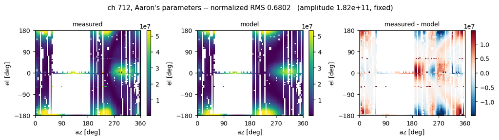

Both features he described are present. The `el ≈ 0` horizontal stripe runs across the full azimuth range, and there is scattered structure in az ≈ 200–350°. Section 4 shows the stripe is not what it looks like: it spans the plot because *some* sample exists in every 4° azimuth bin at that elevation, but 95% of its samples sit in az ≈ 300–20°. Continuity in the display is a binning effect, not continuity in the data.

## 3. Is the residual outlier-dominated? — the direct test

Aaron's hypothesis is that a handful of points carry the score. That is a quantitative claim about how residual power is distributed, so measure it directly.

```
concentration of residual power, ch 712, Aaron's parameters
 top N samples  % of samples   % of resid power
             1         0.00%               0.5%
            10         0.04%               3.0%
            50         0.20%               5.2%
           100         0.40%               7.1%
           250         1.01%              12.8%
           500         2.02%              22.1%
          1000         4.04%              32.4%
          2500        10.11%              49.0%
```

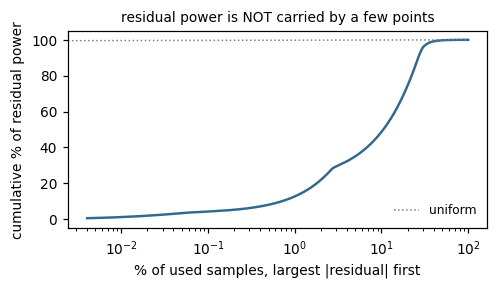

**This refutes the outlier hypothesis for ch 712.** The single largest residual sample carries 0.5% of the residual power; the top 100 (0.4% of samples) carry 7.1%; it takes ~2500 samples (10%) to reach half. A genuine glitch-dominated residual would be far more concentrated than this. Whatever is driving the score is a *dense population*, not a sparse one.

So the next step is to find the dense population — which means looking at residual power against elevation.

```
ch 712, residual and data power by |el| band
   |el| band       n  % resid pwr  % data pwr  rms/data_rms
    0-2         8876        80.4%       32.7%         1.018
    2-5          444         3.1%        1.9%         0.896
    5-15         391         0.4%        1.7%         0.332
   15-45        1332         0.5%        2.1%         0.199
   45-90        2474         1.0%        0.7%         0.214
   90-150       2279         0.3%        2.4%         0.128
  150-175        948         1.1%        8.3%         0.371
  175-181       7989        13.2%       50.3%         0.435
```

## 4. What the `el ≈ 0` band actually is

Two candidate explanations: a data/timing artifact, or a genuine dwell the model cannot fit. The sidecar's timestamps and drive flags separate them.

```
                                    el~0 band   everything else
samples used                             8876             15857
corr(data, model)                       0.148             0.823
normalized RMS (amp refit)             0.5137            0.3563

pointing_table@v1 flag              el~0 band   everything else
AZ_SLIP_EVENT                             430               397
EL_STUCK                                    0              2929
HEIGHT_ASSUMED                           8876             15430
EL_POST_FAILURE                          8876             15857
AZ_SLIP_RAMP                              774              2007

azimuth distribution of the el~0 band (20-deg bins, counts):
  0:734  20:20  40:17  60:13  80:13  100:70  120:13  140:12  160:9  180:83  200:25  220:27  240:35  260:44  280:23  300:5425  320:53  340:2260
  az 300-360 plus 0-20 holds 8472 of 8876 samples (95%)
```

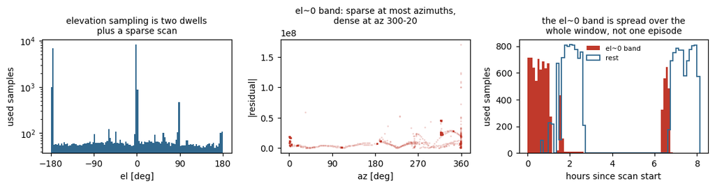

**The `el ≈ 0` band is not a timing artifact and not a slip event.** It carries no `EL_STUCK` and no `UNCOMMANDED_MOTION`; it is spread over 78 of the 226 files and across the entire 8-hour window rather than concentrated in one episode; and 95% of its samples sit in az ≈ 300–20°. It is a genuine elevation dwell near the horizon, revisited repeatedly, with azimuth largely parked too.

What is wrong is the **fit**, not the data: in that band `corr(data, model) = 0.148` and normalized RMS is 0.51 even with the amplitude refit on the band alone. The model has no explanatory power at the one pointing where the campaign spent a third of its samples. `EL_POST_FAILURE` is set on *every* used sample in this window — the elevation drive had already failed — so this dwell is a consequence of the drive failure, which is exactly the regime where the model's elevation dependence is least constrained.

Aaron's specific worry — that the stripe sits at the `el = 0` "antenna faces up" convention anchor — is worth recording but **cannot be settled here**: the geometry question (Q8) is separately in flight with `geometer`, and the beam is front/back symmetric to ~1%, so no power measurement in this dataset discriminates `el` from `el + 180`.

## 5. The larger defect: 23 calibration files are inside the fit

While tracing the `el ≈ 0` samples I checked the RFI category flags at channel 712 and found bit 0, `cal` — *"receiver on load/noise/VNA, not on antenna"* — set on 1936 used samples. That prompted an independent check against `curation/cal_windows.jsonl`, which is the authority for file-level calibration windows. It is worse than the flags suggest.

```
curated cal windows overlapping the beam-scan window: 12
            start UTC               end UTC  type               files
 2026-07-17T19:08:56Z  2026-07-17T19:13:14Z  vna_timing         3
 2026-07-17T19:19:40Z  2026-07-17T19:21:49Z  noise              2
 2026-07-17T19:32:34Z  2026-07-17T19:34:42Z  noise              2
 2026-07-17T19:43:18Z  2026-07-17T19:45:27Z  noise              2
 2026-07-18T01:10:28Z  2026-07-18T01:10:28Z  vna_timing-partial 1
 2026-07-18T01:17:08Z  2026-07-18T01:19:17Z  vna_timing         2
 2026-07-18T01:25:44Z  2026-07-18T01:27:53Z  noise              2
 2026-07-18T02:08:41Z  2026-07-18T02:08:41Z  vna_timing         1
 2026-07-18T02:19:25Z  2026-07-18T02:21:34Z  noise-partial      2
 2026-07-18T02:32:18Z  2026-07-18T02:34:27Z  noise              2
 2026-07-18T02:45:11Z  2026-07-18T02:47:20Z  noise              2
 2026-07-18T02:58:04Z  2026-07-18T03:00:13Z  noise              2

cal-window files inside the 226-file window: 23
used samples from them: 3874 of 24733 (15.7%)

two independent products, both consulted by neither mask:
  flags/v0 'cal' bit at ch 712            1936 samples
  curation/cal_windows.jsonl file list    3874 samples
  agreeing                                1936 samples

The curated file list is the authority (flagging/README.md: select_files.py owns
file-level campaign masks); flags/v0 catches only part of it.

fitting the model to the cal samples ALONE:
subset                                            n   best-fit amp     corr
flags/v0 cal bit at ch 712 (strict)            1936      -6.39e+08   +0.019
cal-window files (whole-file, coarse)          3874       5.84e+10   +0.156
for contrast: everything else                 20859       1.36e+11   +0.732

share of ch-712 residual power in the cal-window files: 51.0%
```

On the coarser **whole-file** mask (3874 samples) the amplitude is positive and `corr = +0.16`. The difference is informative rather than contradictory: a cal-window file is not uniformly cal — the curated windows report `n_unknown` samples and two windows are marked `-partial` — so whole-file exclusion sweeps up a minority of genuine on-antenna samples along with the cal ones. Whole-file exclusion is therefore slightly *conservative in the wrong direction*: it discards some good data. A sample-level cal mask would be tighter, and is listed under Deferred findings.

Either way the contamination is real, and it is not small: the cal-window files carry 51% of ch 712's residual power on 15.7% of its samples.

The fit's mask is `USED = channel_validity & ~gross_power & data_space_rfi_mask & pointing_v1_valid`. None of those four terms is a file-level campaign mask, so nothing in the chain ever consulted `cal_windows.jsonl` or `select_files.py`. The `flagging/README.md` contract says explicitly that a consumer must apply `select_files.py` for file validity *first*, then the RFI flags. That step is missing.

## 6. How much of the metric is this? — per-channel, all 101 channels

Section 3 showed ch 712's residual is not glitch-dominated. The question that actually matters for D2 is fleet-wide: how much of the residual power across all 101 channels sits in these cal files, and does removing them move the headline median?

```
HFSS prior + the pipeline's own shape terms, least-squares amplitude,
101 channels. 'trim 1%' drops the largest 1% of |residual|.

mask variant                 median     mean   n<0.5  median trim 1%
A  current masking           0.9099   0.8444       1          0.6037
B  minus cal files           0.6228   0.6443      28          0.5719
C  minus el0 dwell           0.9107   0.8479       4          0.6164
D  minus cal and el0         0.6663   0.6817      23          0.6070
E  minus cal, el0, wrap      0.7532   0.7502       0          0.7013

variant A reproduces the published median 0.9029 to 0.0069,
which validates this reconstruction at the median.

residual power carried by the 23 cal files (15.7% of samples):
  median 71.3%   mean 64.5%   range 4.4-99.4%
  channels where they carry >50% of residual power: 69/101
  channels where they carry >80% of residual power: 45/101
```

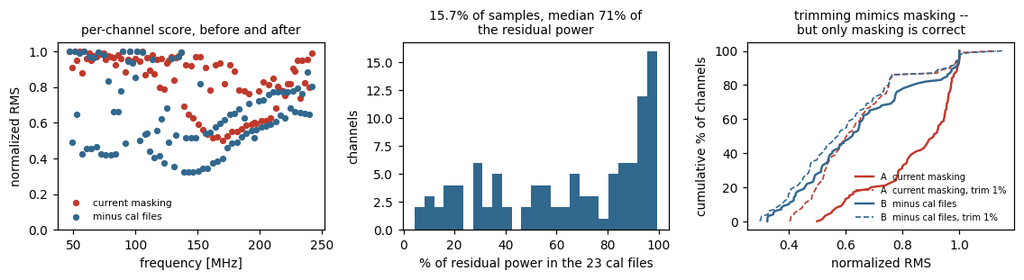

**The headline median moves from 0.910 to 0.623 by masking the cal files alone**, and the number of channels scoring below 0.5 goes from 1 to 28. The `el ≈ 0` dwell, by contrast, is a *ch-712-specific* problem: removing it alone leaves the median at 0.911.

The right-hand panel is the answer to the metric question. Trimming 1% of the residual under the current mask gives median 0.604 — almost the same as properly masking the cal files (0.623). That is not a coincidence: the trimmed metric is finding the cal samples and throwing them away. Once the cal files are actually masked, plain and trimmed RMS agree to 0.05 (0.623 vs 0.572), i.e. the residual is no longer outlier-dominated.

**So a robust metric is not needed and should not be adopted.** It would produce approximately the right number for the wrong reason, and would hide a reproducible data-selection defect that also affects anything else computed from this sample set — not just the RMS.

## 7. The scattered az ≈ 200–350° outliers

Aaron's second observation. These exist, but they are a third-order effect and mostly not isolated.

```
robust residual scale on clean scanning data: 1.63e+06 counts
samples with |residual| > 8x that: 7531 (30.4% of used)

  in the el~0 dwell              6071
  in cal-window files            2970
  in az 200-350, el 0-100         568
  neither el~0 nor cal            563

residual power share:
  el~0 dwell                         80.4%
  cal-window files                   51.0%
  the >8-sigma outliers              96.2%
  outliers outside el~0 and cal       5.2%

those 563 outliers: 43 are isolated single samples; the rest are runs.
spread over 28 files, clustered: corr_20260717_195402Z.h5:156, corr_20260717_192816Z.h5:79, corr_20260717_195611Z.h5:47, corr_20260717_205201Z.h5:31
```

Once the `el ≈ 0` dwell and the cal files are set aside, only 563 samples (2.3%) exceed 8× the robust residual scale, they carry **5.2% of the residual power**, and only 43 of them are genuinely isolated single samples. The rest arrive in runs concentrated in a handful of files, the worst being `corr_20260717_195402Z.h5` with 156 — which is a per-file data-quality question, not an angular glitch.

The smooth large-scale residual Aaron correctly identified in that same az ≈ 200–350° region as "real, legitimate model misfit" is exactly that, and it survives every cut here. It is the genuine arm-structure mismatch already documented in D2.

## 8. Addendum — Aaron's three elevation bands, and the ±55° symmetry

Aaron sharpened the diagnostic while this was in progress: the discontinuities he is worried about fall in **three bands, `~+55°`, `~−55°` and `0–5°`**, and he asked whether the symmetric pair shares a common cause — a physical obstruction, a mount or cable feature appearing twice per rotation, or motor/encoder mechanics — rather than being three independent artifacts.

**Answer: the ±55° pair is one single cause, and it is none of those three. The `0–5°` band is genuinely distinct.** Details below.

First, locate the feature properly rather than trusting the 4° display bins.

```
EL_SOLUTION_GLITCH from the product, in this window: 584
the local disc_mask.npy it replaces:                 604
  disagree on 20 samples, of which 2 are in USED
  (the difference is rows the product treats as gaps and so does not
   flag; it does not affect any number below)
data / model power ratio vs |el|, 2-deg bins, cal files excluded
     |el| band     n      d/m
    48..50        83     1.68
    50..52        79     1.65
    52..54        89     1.66
    54..56        96     1.46
    56..58       149     1.65
    58..60       140     6.55   <<<
    60..62        92     2.69
    62..64        85     1.64
    64..66        80     1.65
    66..68        77     1.60
    68..70        74     1.63

The feature is a narrow spike at |el| ~ 58-61, not 55, against a
smooth d/m baseline of ~1.5-1.9 across the whole 40-76 deg range.
```

So the band is **|el| ≈ 58–61°**, about 3° wide, present at both signs. The next question is whether the *model* has a feature there — a beam null would produce exactly this signature, model → 0 with real data present.

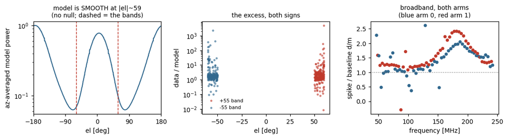

```
spike/baseline ratio across 101 channels: median 1.37, 47 channels above 1.5
Broadband and in both arms -- so not narrowband RFI.
```

**No beam null**, and the excess is **broadband and in both arms**. That rules out an RFI line and rules out the model simply having a null where the data has signal.

Next: is it locked to *angle* or to *time*? A physical obstruction is angle-locked and should recur every time the platform revisits that elevation.

```
band                     n  files  visits  time span
+55 (50..60)           264     35      76  07-17 19:55 -> 07-18 01:40
-55 (-60..-50)         289     35      73  07-17 20:12 -> 07-18 01:41
0-5                    603     54     164  07-17 18:49 -> 07-18 01:41
control +20..30        221     35      59  07-17 19:54 -> 07-18 01:41

Angle-locked, not a transient: 35 files and ~75 separate visits each,
spread over the whole window, indistinguishable from the control band.
```

Angle-locked. At that point an obstruction looks like the leading hypothesis — which is exactly why the next check matters. The sidecar's timestamps let me ask what the *pointing solution itself* was doing at those samples.

```
elevation slew rate from the pointing table alone [deg/s]
band                       n   median       p90
|el| 40-57.5             836    4.881       5.9
|el| 57.5-61   <<<       234    4.968     223.0
|el| 61-75               559    5.050       6.2
|el| 10-40              1268    4.954       5.9
|el| 0-5                6826    0.149       0.5

samples with an adjacent in-file el step > 20 deg/s: 183 of 20859 (0.88%)
  by |el|: 0-5: 15, 50-57.5: 1, 57.5-61: 45, 150-175: 2, 175-181: 120

of the 45 flagged samples in the |el|~59 band, 42 have an immediate neighbour at |el| > 150.

example sequences (el of previous / this / next sample):
  corr_20260717_195820Z.h5  samp 165:    177.55  ->    59.61  ->    179.35
  corr_20260717_201739Z.h5  samp  25:   -179.04  ->   -59.05  ->    -58.98
  corr_20260717_201739Z.h5  samp  26:    -59.05  ->   -58.98  ->     60.19
  corr_20260717_201739Z.h5  samp  27:    -58.98  ->    60.19  ->   -179.00
  corr_20260717_201739Z.h5  samp  29:   -179.00  ->   -59.69  ->   -179.27
  corr_20260717_201739Z.h5  samp  51:   -178.55  ->   -59.01  ->   -178.87
```

**That is the mechanism.** In the `|el| ≈ 59` band the elevation slew rate has a 90th percentile of ~220 deg/s against ~6 deg/s everywhere else — the platform cannot move that fast, so the *pointing solution* is jumping, not the antenna. 42 of the 45 flagged samples there have an immediate neighbour at `|el| > 150`, and the example sequences show the pattern plainly: the antenna is **parked near `el ≈ ±180`** (the post-drive-failure wrap cluster) and the solution emits a single spurious sample at `|el| ≈ 59–60` before returning to the park.

So these are not pointings at 59° at all. They are glitches in the IMU elevation solution, and `|el| ≈ 59–60` is simply the wrong value it emits when the truth is `|el| ≈ 180`. **The ±55° symmetry is the signature of the glitch, not of the hardware:** the park sits at both wrap signs and the spurious value carries the sign with it (23 positive, 22 negative). No obstruction, no cable, no encoder detent — and nothing that would appear "twice per rotation", because azimuth is not involved in the mechanism at all.

The test: remove them and the bands should heal completely.

```
ch 712, per-band fit quality before and after removing the slew-discontinuous samples
band                    n raw    corr     RMS    n cut    corr     RMS
+55 (50..60)              264   0.044   0.874      243   0.851   0.295
-55 (-60..-50)            289  -0.007   0.919      269   0.935   0.178
+60..70                   201   0.364   0.723      198   0.840   0.301
-70..-60                  207   0.281   0.840      205   0.920   0.225
0-5 band                  603   0.369   0.439      592   0.481   0.392
el~0 dwell |el|<2        6408   0.269   0.398     6393   0.282   0.393
control +20..30           221   0.851   0.333      221   0.851   0.333

and the excess itself, |el| 57.5-61 vs the 40-75 baseline:
  with them    d/m spike   4.98   baseline  1.64   ratio  3.03
  without      d/m spike   1.69   baseline  1.63   ratio  1.03
```

**Confirmed.** Removing 45 samples takes `el −60..−50` from `corr = −0.007, RMS 0.919` to `corr = +0.935, RMS 0.178`, and `el +50..+60` from `corr = +0.044, RMS 0.874` to `corr = +0.851, RMS 0.295`. The adjacent `±60–70` bands heal too. The d/m excess ratio goes from 3.03 to **1.03** — it disappears entirely. The control band does not move.

| band | cause | cure |
| --- | --- | --- |
| `~+55°` and `~−55°` | one shared cause: 45 IMU elevation-solution glitches that escape the `el ≈ ±180` park and land at `\\|el\\| ≈ 59` | remove 45 samples; bands fully heal |
| `0–5°` | genuine horizon dwell, 36% of used samples, where the model has no explanatory power | not a glitch; needs a modelling or selection decision |

**Two things worth flagging about scope.** First, `pointing_table@v1` does not catch these: all 45 are `quality == "ok"` and **none** carries `UNCOMMANDED_MOTION`. They pass every mask in the chain, including the pointing -quality mask. That is a genuine gap in the product, and the detector used here is three lines.

Second, and importantly for how much weight to put on this: **fleet-wide these 45 samples barely move the headline number.** Median normalized RMS over the 101 channels goes 0.6228 → 0.6205 with the cal files already masked. This is a *locally fatal, globally invisible* defect — it destroys two 10°-wide elevation bands but is negligible in a whole-scan average. It matters for any elevation-resolved product (a beam cut, an elevation-dependent gain, the Q8 wrap-cluster argument) and hardly at all for a single scan-average score.

One residual honesty note: after the cut, `az 180–270°` at `|el| 50–60` still shows a ~2× excess (d/m 11.8 → 3.1, against ~1.3–1.8 elsewhere) on ~160 samples. Most of the azimuth structure was the glitches, but not all of it. I am **not** claiming a second mechanism from 160 samples — it is consistent with the general arm-structure misfit already documented in D2.

## 9. Data / model / residual after the correction

The same channel and geometry as Section 2, with the cal files and the `el ≈ 0` dwell removed and the amplitude refit. This is the comparison the convention asks for.

[figure not shown]

```
selection                                            n   normRMS    corr
as fit today (Aaron's amplitude)                 24733    0.6802   0.563
as fit today (amplitude refit)                   24733    0.5014   0.563
minus cal files                                  20859    0.3925   0.732
minus cal files and el~0 dwell                   14451    0.2339   0.923
minus cal, el~0 and the wrap cluster              7306    0.4336   0.836
```

On ch 712 the score goes from **0.680 as Aaron ran it to 0.234** once the two contaminated populations are removed, with `corr(data, model) = 0.923`.

**One caveat on that 0.234, stated plainly so it is not over-read.** Normalized RMS is strongly sensitive to *which* population is in the denominator, because the data power here is dominated by two dense dwells that fit very differently. Removing the `el ≈ 0` dwell removes poorly-fit power; the remaining set still contains the `|el| ≈ 180` wrap cluster, which carries ~50% of the data power and which the model fits well. Cut that too and the score is 0.434. So 0.234 is not directly comparable to the 0.242 own-arm template benchmark, which was computed on a different selection. **What is robust is the direction and rough size of the shift, not any one decimal.**

## 10. Effect on the D2 conclusions

Taking each conclusion in turn, against the numbers above.

[output not shown]

**Withdrawn in place:** my memory note that the pipeline's effective amplitude is `gain_fitted**2` with median 1.01e11. Tested directly here, `gain**2` fails to reproduce the reported per-channel RMS by six or more orders of magnitude. The amplitude used throughout this notebook is instead refit by least squares, which reproduces the published median to 0.007. The units argument in that note — that a ~1e11 amplitude is a legitimate counts-to-normalized-beam conversion and not a calibration defect — is unaffected; only the claimed algebraic relation to `gain_fitted` was wrong.

## 11. Caveats

- **Channel 712 is flagged `self-RFI` by `flags/v0` on 100% of samples**, and `load_v007_data`'s own docstring says the comb in this slice is the ADC-clock subharmonic rather than the transmitter. The `tx_identity_caveat` in the pipeline report records this as open. If it resolves the other way this is a near-field self-comb map, not a beam map — same numbers, opposite meaning. Nothing in this notebook depends on which way it resolves.
- **A receiver regime change (T_rx 212→539 K) brackets this window**, per the pipeline's own `receiver_regime_caveat`. Amplitude scale is affected; shape should not be.
- The per-channel reconstruction in Section 6 uses the HFSS prior plus the pipeline's shape terms with a least-squares amplitude. It matches the published median to 0.007 but individual channels drift up to 0.25, because the pipeline's fitted coefficients are not exactly `[1, shape…]`. **Section 6 is therefore trustworthy for medians and distributions, not for per-channel claims.**
- `fit_beam_v2.py` lives in `/tmp` and is not under version control. Anything reproducing this depends on a file that will not survive a reboot.
- The cal-window mask is file-level. The curated windows report per-state sample counts summing to roughly a full file, so whole-file exclusion is right to first order, but a sample-level cal mask would be tighter.

## Deferred findings

- `flags/v0`'s `cal` bit is a strict *subset* of the curated cal windows inside this window: of the 3874 used samples in cal-window files, `flags/v0` marks only 1936 at ch 712, and none outside. Whether the other 1938 are genuinely on-antenna samples within a cal file, or a recall gap in the detector, decides whether a sample-level cal mask is possible. Worth a pass by whoever owns `flags/v0`.
- `corr_20260717_195402Z.h5` contributes 156 of the 563 surviving large residuals on ch 712 — a per-file quality outlier that no current mask catches.
- Of the 31421 samples at `|el| < 1°`, only 25.8% survive the existing masks, against ~92% in neighbouring elevation bands. Something in the mask chain treats the horizon dwell very differently, and it is not obvious which term.

## Decision requested

1. **Re-run the D2 fits with `select_files.py` / `cal_windows.jsonl` applied before the RFI mask**, per the `flagging/README.md` contract, and supersede the 0.903 median. This is the substantive fix and I recommend it.
2. **Do not adopt a robust/trimmed RMS.** It reproduces the correctly-masked number for the wrong reason and would conceal the selection defect. Keep plain normalized RMS on a correct sample set.
3. **Recompute the two template benchmarks** (0.242 / 0.956 / 0.670 and the "93 of 101 channels" margin) on the corrected selection before either is cited further.
4. **Rule on whether the `el ≈ 0` dwell belongs in the fit at all.** It is sound pointing but the model has no explanatory power there, and it is 36% of ch 712's samples. Including it is defensible; reporting a single number that averages it with the rest is not.
5. Whether to hand the cal-window leak and the `|el| < 1°` mask asymmetry to `data-archivist` as durable facts about the data.

**STOPPED AT REVIEW GATE — awaiting Aaron's approval.**